# Exercise 1 - K Means

Given the following artificial data set which is unlabeled:

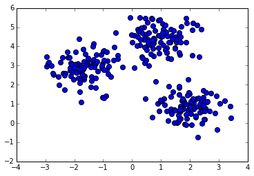

```python
%matplotlib inline
import matplotlib.pyplot as plt
import numpy as np

from sklearn.datasets.samples_generator import make_blobs
X, y = make_blobs(n_samples=300, centers=3,
                  random_state=0, cluster_std=0.60)
plt.scatter(X[:, 0], X[:, 1], s=50);
```

Use the K-means algorithm included in scikit-learn using 3 clusters to fit the data $X$ above and plot the data color coded for the estimated cluster each data point belongs to.

Your final plot should look something like the following figure:

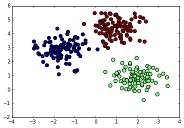

# Exercise 2 - K-Nearest neighbors

Let's move now to a classification task. You are going to work with a data set contained in the file video_store_2.csv available in the I: drive folder of the Assignment. This is a data set with just 50 instances of customer behavior in a video store. The data contains 8 columns:

- customer ID
- gender
- income
- Age
- rentals (Total number of rentals that the customer has done)
- average per visit (Average number of rentals per visit to the store)
- Genre (The most prevalent type of movie that they rent)
- Incidentals (Whether a particular customer has generated trouble by for instance not returning a rental in time)

We will discard the first column (Customer ID) and use the columns gender, income, age, rentals, average per visit, genre as predictors $X$ (features) for the target variable $y$ Incidentals.

We start by loading the data. Assuming your python script is in the same folder as the data file. You need to carry out a bit of data cleaning and arrangement before you are ready to work with the data, but I provide you with all the necessary code so you don't need to worry about that. Copy and paste the following code so you end up with the stereotypical $X$ matrix and $y$ vector:

```python
import numpy as np
vs = np.genfromtxt("video_store_2.csv", delimiter=",", names=True, dtype=(int, "|S1", float, int, int, float, "|S10", "|S3"))
vs_records = vs[['Gender','Income','Age','Rentals','Avg_Per_Visit','Genre']]
vs_names = vs_records.dtype.names
vs_dict = [dict(zip(vs_names, record)) for record in vs_records]
from sklearn.feature_extraction import DictVectorizer
vs_vec = DictVectorizer()
X = vs_vec.fit_transform(vs_dict).toarray()
y = vs['Incidentals']
```

We now move on to the traditional splitting of the data into 2 sets: training and testing. This time however, we will use 80% of the data for training.

```python
tpercent = 0.8
tsize = tpercent * len(X)
X_train = X[:tsize,:]
X_test = X[tsize:,:]

y_train = y[:tsize]
y_test = y[tsize:]
```

We are almost ready to carry out classification on the training data. However, there is one last detail we need to fix. If you open up the matrix **X** or **X_train** in Spyder, you will notice that among the 9 features present, there is a wide range of scales being used. Some columns have values in the range [0,1], while others (Income) oscillate in the range [1000,89000]. As I have explained during lectures, such a wide distribution of scales is not good for a learning algorithm. Hence, we need to normalize/transform the features to similar scales while maintaining the information contained in the data. This procedure is called feature scaling (bringing all the features to a similar range [0,1] for instance). Doing so is fairly straightforward in scikit–learn.

```python
from sklearn import preprocessing
min_max_scaler = preprocessing.MinMaxScaler()
X_train_norm = min_max_scaler.fit_transform(X_train)
X_test_norm = min_max_scaler.fit_transform(X_test)
```

Examine, The matrices **X_train_norm** or **X_test_norm** And notice how all the values now lie in the range [0,1].

Finally, use the K nearest neighbors classifier in scikit-learn to fit the data (use k=5). Use the predict method to carry out prediction of the classifier on the test data. You should get a classification accuracy of around 50% which is not very good, but we are working with a challenging data set.

# Exercise 3 - Error analysis: Precision and recall

Print out a detailed analysis of precision versus recall for the KNN algorithm above.

# Exercise 4 - Support vector machines

Now use a support vector machine classifier with a nonlinear kernel (kernel='rbf') to build a model using X_train_norm, y_train and to carry out prediction on X_test_norm. Print out a detailed analysis of precision versus recall. Classification accuracy should improve to around 71%.

# Exercise 5 - Logistic regression

Now use a Logistic regression classifier to build a model using X_train_norm, y_train to carry out prediction on X_test_norm. Print out a detailed analysis of precision versus recall. Classification accuracy should also be around 71%. Oddly, if you use the data prior to normalization (feature scaling) you will get even better classification accuracy, but this is usually not the case.

# Exercise 6 - Principal Component Analysis

We first create 200 random two-dimensional data points. The data points are sampled from a multinomial normal distribution. You don't have to understand precisely how we do this.

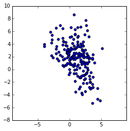

```python
%matplotlib inline
import matplotlib.pyplot as plt
import numpy as np
Cov = np.array([[2.9, -2.2], [-2.2, 6.5]])
X = np.random.multivariate_normal([1,2], Cov, size=200)
plt.figure(figsize=(4,4))
plt.scatter(X[:,0], X[:,1])
plt.axis('equal') # equal scaling on both axis;
plt.show()
```

Use PCA to find out the 2 principal components of the data. Please, print out those 2 components and the percentage of variance explained by each one of those components.

# Exercise 7 - Artificial neural networks

The following image illustrates a very simple artificial neuron network implementing a logic OR function. What would be the output of this artificial neuron network if the input vector is $x=(1,0)$

[figure not shown]

# Exercise 8 - Validation

In your own words, explain what the last two lines of code do in the following code snippet:

```python
from sklearn.datasets import load_digits
digits = load_digits()
X = digits.data
y = digits.target

from sklearn.neighbors import KNeighborsClassifier
from sklearn.cross_validation import cross_val_score
cv = cross_val_score(KNeighborsClassifier(1), X, y, cv=10)
cv.mean()
```

```
0.97614938602520218
```

# Exercise 9 - Regularization

We load next The Boston housing data set containing a bunch of predictors (features) of houses and the associated price.

```python
from sklearn.datasets import load_boston
boston = load_boston()
```

We split the data in a training and a test set:

```python
from sklearn.cross_validation import train_test_split
X_train, X_test, y_train, y_test = train_test_split(boston.data, boston.target, test_size=0.5, random_state=0)
```

Examine the code below. In your own words, explain why the Coefficients (parameters) of model "ridgeRegr" are smaller than those of model "regr".

```python
from sklearn import linear_model
regr = linear_model.LinearRegression()
regr.fit(X_train, y_train);
print regr.coef_

print "-------------------"

from sklearn import linear_model
ridgeRegr = linear_model.SGDRegressor(loss='squared_loss', penalty='l2') #Hint: The answer to the 1st question lies here
ridgeRegr = linear_model.Ridge(alpha = 10000)
ridgeRegr.fit(X_train, y_train)
print ridgeRegr.coef_
```

```
[ -1.22697052e-01   5.76835439e-02   7.42047961e-02   3.38949970e+00
  -1.65391519e+01   3.57730248e+00  -2.98033902e-03  -1.55759520e+00
   2.50098217e-01  -9.73850155e-03  -1.12527834e+00   6.85073312e-03
  -5.92410460e-01]
-------------------
[ -8.13191022e-02   7.88595689e-02  -3.45432534e-02   8.42665464e-03
   3.40347049e-05   6.72188436e-02   1.92473899e-02  -7.62272258e-02
   7.11550968e-02  -1.25711659e-02  -1.30120768e-01   1.06545857e-02
  -4.02238603e-01]
```

### Deliverables

- You should hand in a single python file containing the necessary code to answer each of the previous enumerated bullet points.
- You can include comments in the code to clarify your answer to each item.
- For exercises That do not require coding, just type the correct answer as a comment in the file that you're going to hand in.
- Please, make sure your code runs smoothly so I can execute it in my computer.
- Name your file according to the following pattern: yourLastName_DB3Assignment2.py
- Drop the file containing your assignment in the swallow box at location "M:\Assessments Swallow Box\IN705Databases3\Project2"
- The due date for handing in the assignment is Friday the 13th of November at 5pm.

** Final note: ** If you get a good grade in this assignment, you should feel very confident and very proud about the skills you have acquired in the field of data mining/machine learning.